# generated_series

## 5.1 Построение явной формулы для сигнала

### 5.1.1 Модельный ряд без шума

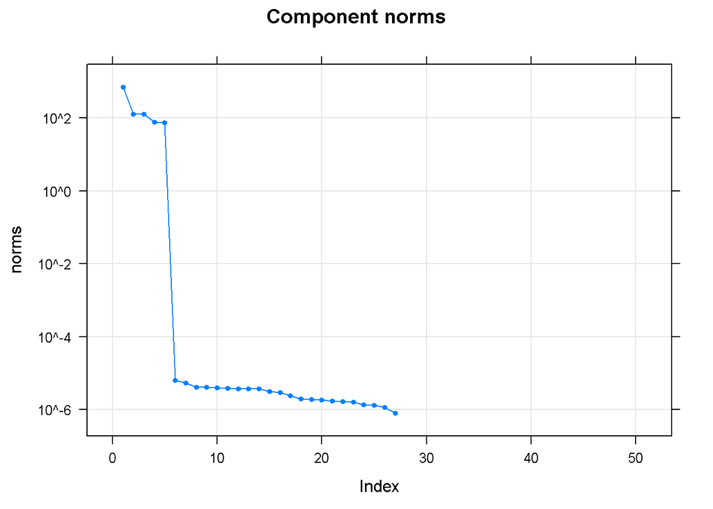

```r
SSAbrth <- ssa(ser, L = 50)
SSAbrth_e <- ssa(ser_e, L = 50)
plot(SSAbrth)
```

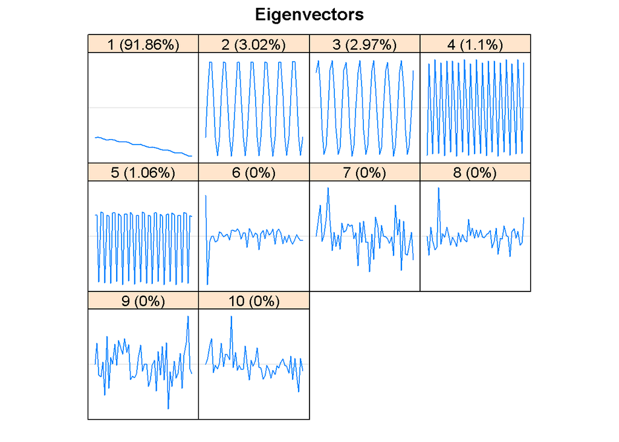

```r
plot(SSAbrth, type = "vectors", idx = 1:10)
```

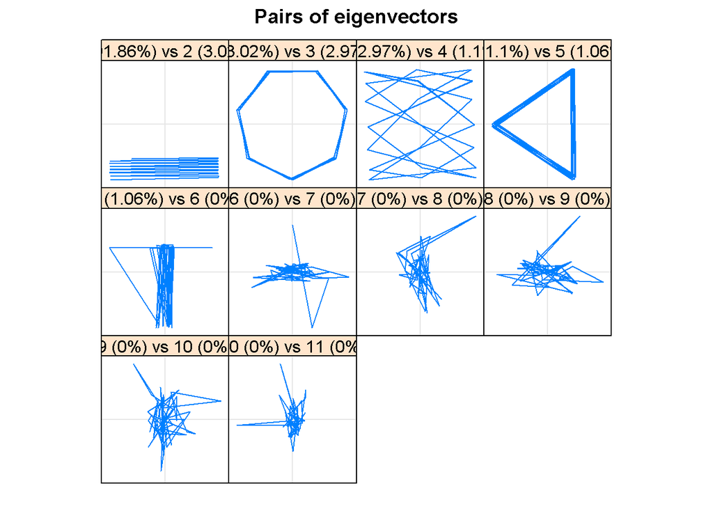

```r
plot(SSAbrth, type = "paired", idx = 1:10)
```

Рассмотрим сигнальные корни на окружности $\mu_m$.

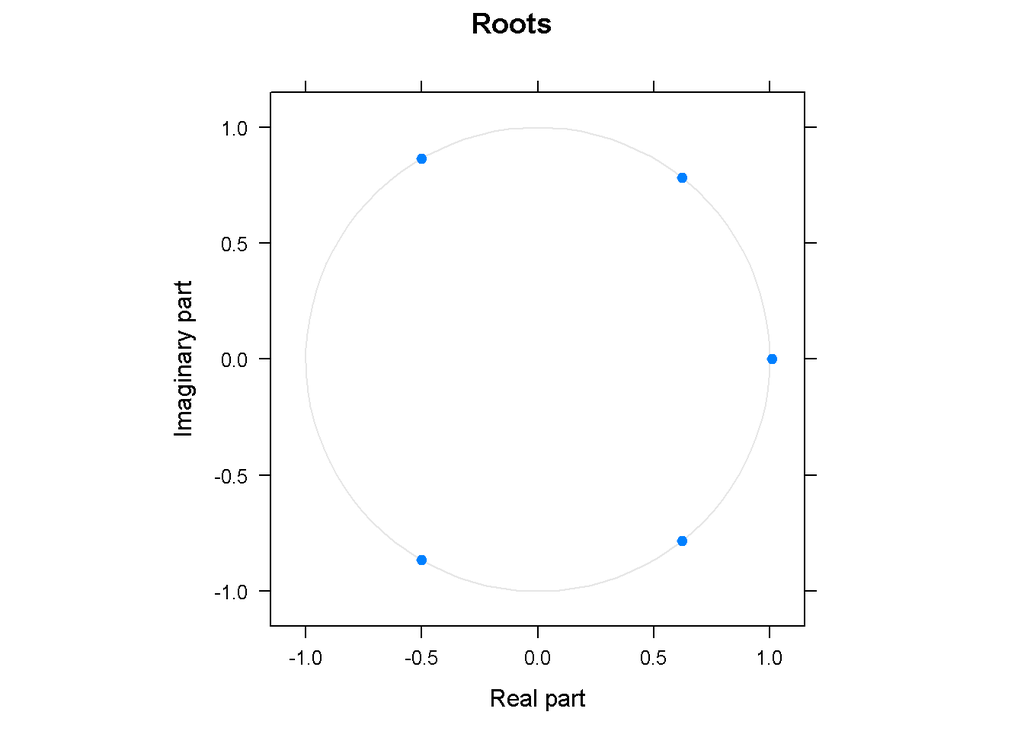

```r
root_<-parestimate(SSAbrth, groups = list(c(1:5)), method = "esprit")
root_s<-root_$roots
#parestimate(SSAbrth_e, groups = list(c(1:5)), method = "esprit")
plot(root_)
```

Пусть $x_n=\sum_{m=1}^{d}C_m\mu_m^n$

$$x_1=\sum_{m=1}^{d}C_m\mu_m \\ x_2=\sum_{m=1}^{d}C_m\mu_m^2 \\ \ldots \\ x_d=\sum_{m=1}^{d}C_m\mu_m^d$$

Или если записать в матричном виде:
$$X=\begin{pmatrix}
\mu_1 &\ldots & \mu_d\\
\mu_1^2 & \ldots & \mu_d^2\\
\ldots & \ldots & \ldots \\
\mu_1^d & \ldots & \mu_d^d
\end{pmatrix}C = WC$$

Находим коэффициенты: $C=W^{-1}X$

```r
X<-ser[1:5]
Matrix_W<-function(n){mapply(function(root){root^(1:n)}, root_s)}
W <- Matrix_W(5)
c<-Re(solve(W)%*%X)
c
```

```
##      [,1]
## [1,]  8.0
## [2,]  2.5
## [3,]  2.5
## [4,]  1.5
## [5,]  1.5
```

Строим явную формулу для каждого значения ряда

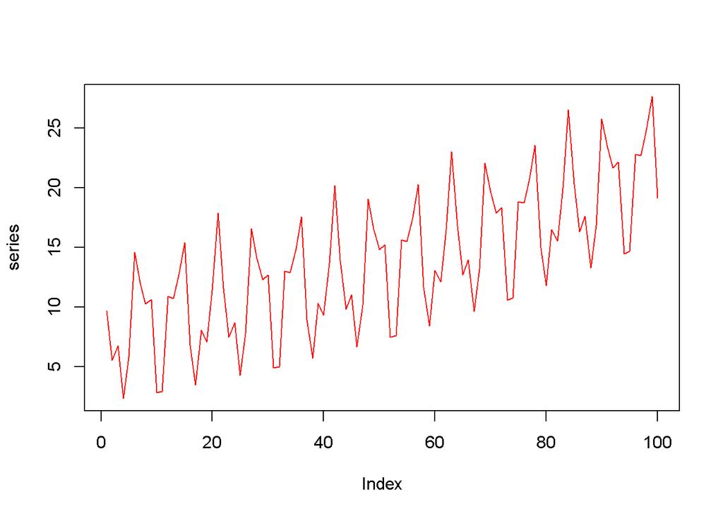

```r
LRF <- function(n){
return(Re(mapply(function(root){root^(n)}, root_s)%*%c) ) }

plot(ser, type = 'l', ylab = "series")
lines( LRF(1:100), type = 'l',col = 'red')
```

Видим, что графики совпали.

### 5.1.2 Модельный ряд с шумом

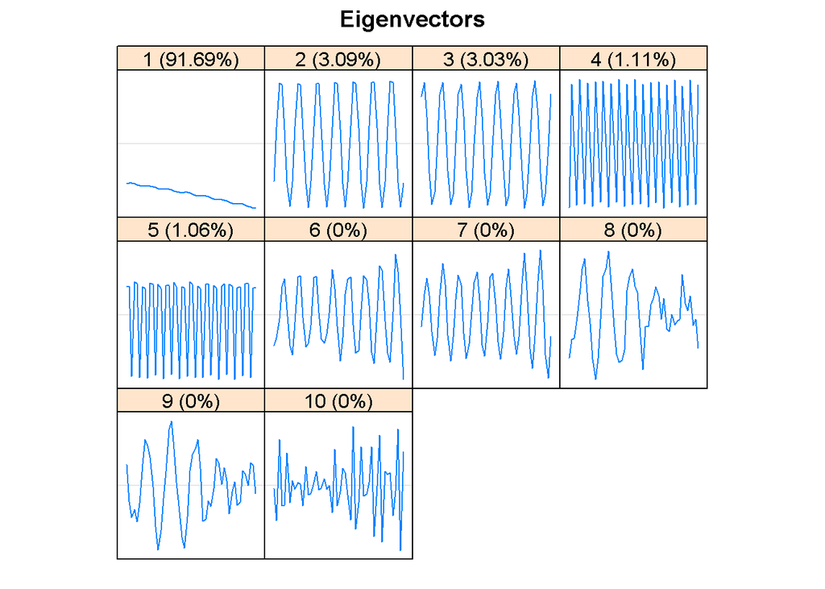

```r
plot(SSAbrth_e, type = "vectors", idx = 1:10)
```

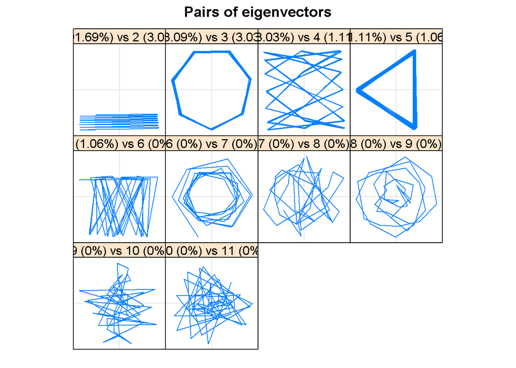

```r
plot(SSAbrth_e, type = "paired", idx = 1:10)
```

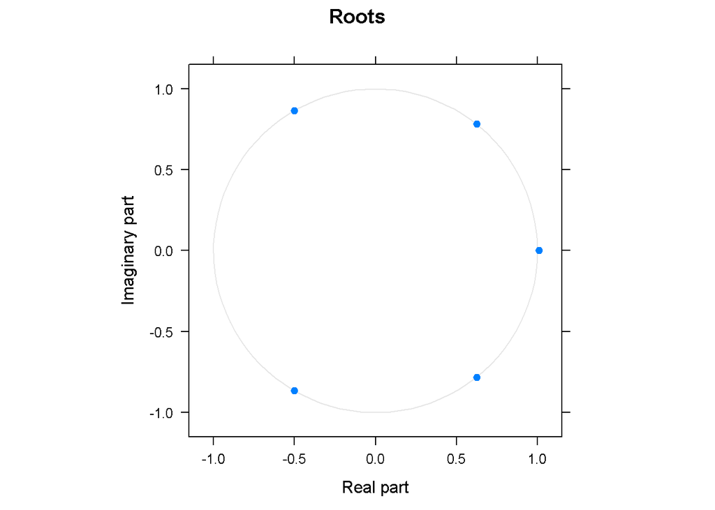

```r
root_e<-parestimate(SSAbrth_e, groups = list(c(1:5)), method = "esprit")
root_se<-root_e$roots
plot(root_e)
```

Находим коэффициенты: $C=W^{-1}X$

```r
signal <- reconstruct(SSAbrth_e , groups = list(c(1:5)))
Matrix_W<-function(n){mapply(function(root){root^(1:n)},root_se)}
W <- Matrix_W(length(signal$F1 ))
c <- solve(t(W) %*% W) %*% t(W)%*%signal$F1
c
```

```
##                    [,1]
## [1,] 7.957199-0.000000i
## [2,] 2.464814+0.026065i
## [3,] 2.464814-0.026065i
## [4,] 1.536402+0.008215i
## [5,] 1.536402-0.008215i
```

Строим явную формулу для каждого значения ряда

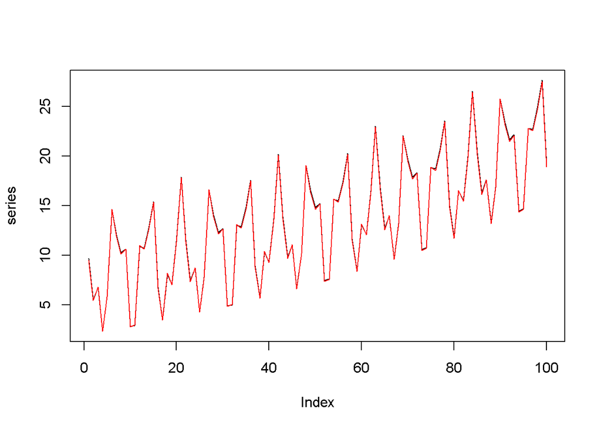

```r
LRF <- function(n){
return(Re(mapply(function(root){root^(n)}, root_s)%*%c) ) }

plot(ser, type = 'l', ylab = "series")
lines( LRF(1:100), type = 'l',col = 'red')
```

Видим, что графики немного различаются из-за шума.

### 5.1.3 Реальный ряд

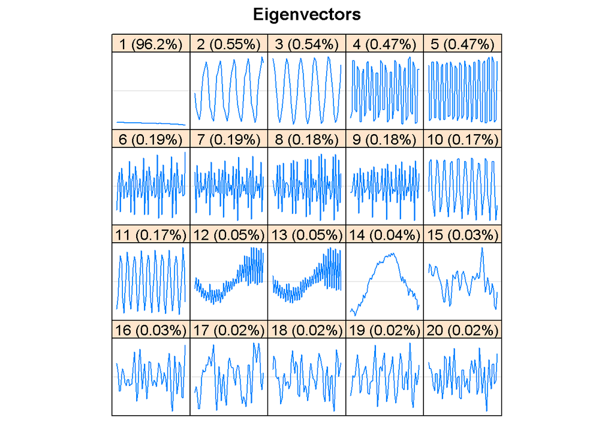

```r
signal <- reconstruct(ssa_fort, groups = list(c(1:14)))
plot(ssa_fort, type = "vectors", idx = 1:20)
```

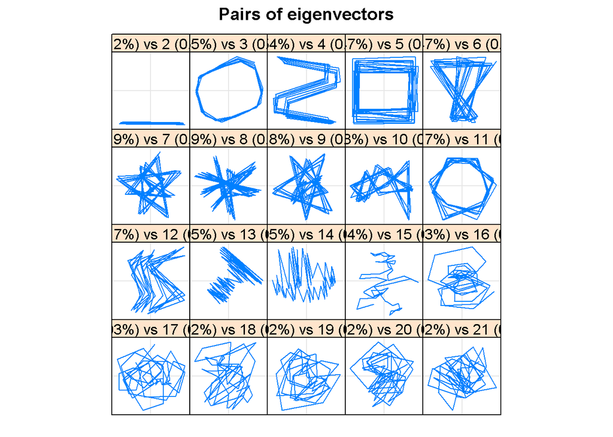

```r
plot(ssa_fort,  type = "paired", idx = 1:20)
```

Ранг сигнала беру 14(количество компонент, которые мы относим к сигналу). Смотрим сигнальные корни на окружности.

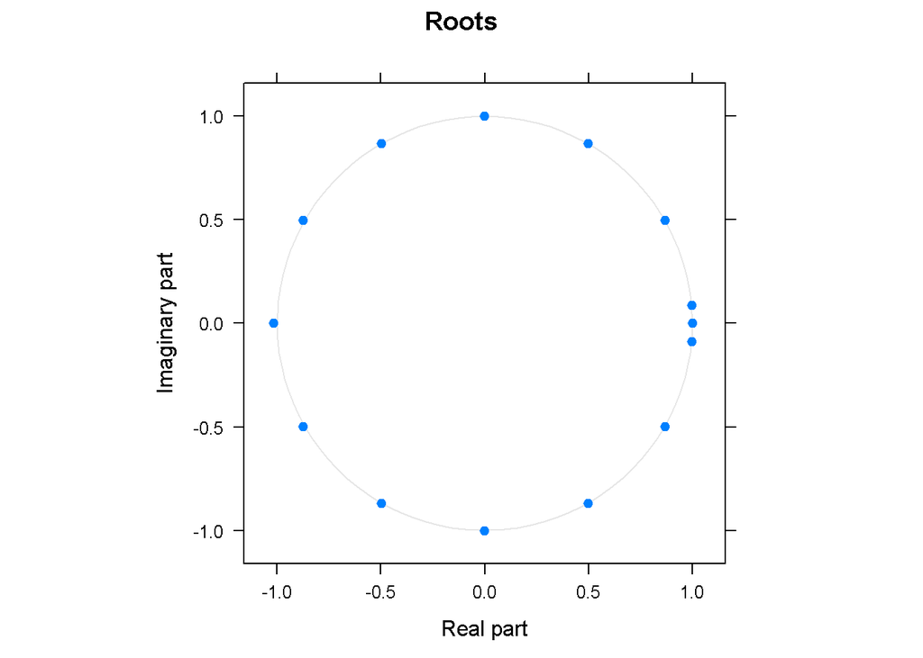

```r
root_fort<-parestimate(ssa_fort, groups = list(c(1:14)), method = "esprit")
plot(root_fort)
```

```r
root_fort$roots
```

```
##  [1] -1.0179845-0.0000000i -0.8762936+0.4979118i -0.8762936-0.4979118i
##  [4]  0.4990539+0.8699234i  0.4990539-0.8699234i -0.0003092+1.0016926i
##  [7] -0.0003092-1.0016926i  1.0015699+0.0000000i -0.4989917+0.8681590i
## [10] -0.4989917-0.8681590i  0.8688452+0.4977169i  0.8688452-0.4977169i
## [13]  0.9973296+0.0862724i  0.9973296-0.0862724i
```

Находим коэффициенты.

```r
Matrix_W<-function(n){mapply(function(root){root^(1:n)},root_fort$roots)}
W <- Matrix_W(length(signal$F1))
c <- solve(t(W) %*% W) %*% t(W)%*%signal$F1
c
```

```
##                        [,1]
##  [1,]   10.07757-  0.00000i
##  [2,]   44.44380- 41.05411i
##  [3,]   44.44380+ 41.05411i
##  [4,]   89.67579+ 46.13883i
##  [5,]   89.67579- 46.13883i
##  [6,]  139.73701+139.23251i
##  [7,]  139.73701-139.23251i
##  [8,] 2795.41306-  0.00000i
##  [9,]   56.03189+110.07903i
## [10,]   56.03189-110.07903i
## [11,]   56.74102+200.54638i
## [12,]   56.74102-200.54638i
## [13,]  -54.62643-  8.51644i
## [14,]  -54.62643+  8.51644i
```

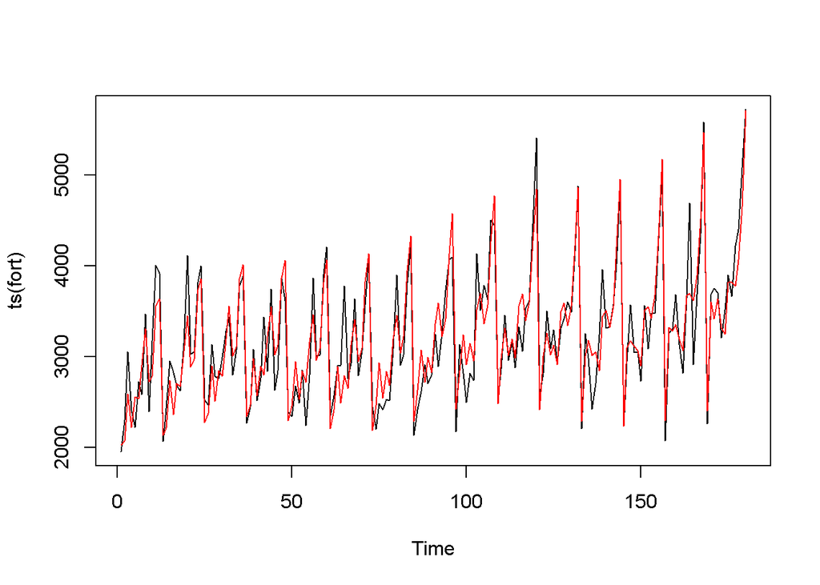

```r
LRF <- function(n){
return(Re(mapply(function(root){root^(n)}, root_fort$roots)%*%c) ) }
plot(ts(fort))
lines( LRF(1:180), type = 'l',col = 'red')
```